# 03 - Spatial Data in R

Bryan Milstead

## Introduction

Over the past few years there has been a rapid increase in the ability of R to handle spatial data. New packages are being added continuously and the functionality of R now rivals some of the big names in GIS software. R can now handle both vector and raster data and has good options for geoprocessing. For most task we find that R runs faster than the commercial alternatives plus you have the added benefit of being able to script your analyses. Interactive visualization of spatial data still needs improvement but we expect to see this last obstacle overcome soon. As with any type of R analysis there is a steep learning curve but once you have mastered the basics you will find that R is a good solution for your spatial analyses.

In this part of the workshop we will go over the basics of using R for spatial analysis. This is a big subject so we will only scratch the surface but the exercises will give you a good introduction of the capabilities of R in this area.

Much of this lecture was adapted from a workshop given by Jeff Hollister. You can see the materials from his recent workshop here: [Hollister Workshop](http://scicomp2014.edc.uri.edu/posts/2014-02-04-Hollister.html)

## Lesson Goals

- Beginning understanding of `sp` (spatial) objects in R
- Brief introduction to R packages for Spatial Analysis
- Learn how to read shapefiles into R
- Explore how to visualize `sp` objects in R
- Conduct a basic GIS analysis in R

## Quick Links to Exercises

- Exercise 1: Getting spatial data into R
- Exercise 2: Visualizing spatial data in R
- Exercise 3: Working with rasters

## Spatial Objects

### Overview of Classes and Methods

- Class: object types
  - class(): gives the class type
  - typeof(): information on how the object is stored
  - str(): how the object is structured
- Method: generic functions
  - print():
  - plot()
  - summary()

### Subclasses of Spatial Objects

- This is a big topic that we will only touch upon. For more information see Bivand, R. S., Pebesma, E. J., & Gómez-Rubio, V. (2008). Applied spatial data analysis with R. New York: Springer.
- We can use the “getClass()” command to view the subclasses of spatial objects.

```r
library(sp)
getClass("Spatial")
```

```
## Class "Spatial" [package "sp"]
##
## Slots:
##
## Name:         bbox proj4string
## Class:      matrix         CRS
##
## Known Subclasses:
## Class "SpatialPoints", directly
## Class "SpatialGrid", directly
## Class "SpatialLines", directly
## Class "SpatialPolygons", directly
## Class "SpatialPointsDataFrame", by class "SpatialPoints", distance 2
## Class "SpatialPixels", by class "SpatialPoints", distance 2
## Class "SpatialGridDataFrame", by class "SpatialGrid", distance 2
## Class "SpatialLinesDataFrame", by class "SpatialLines", distance 2
## Class "SpatialPixelsDataFrame", by class "SpatialPoints", distance 3
## Class "SpatialPolygonsDataFrame", by class "SpatialPolygons", distance 2
```

## Packages for Using R as a GIS

The standard packages that give GIS functionality to R are listed below with a bit of annotation on each.

1. `sp`: This is one of the foundational packages for dealing with spatial data in R. It sets up the spatial data classes (e.g. `SpatialLines`, `SpatialPolygonsDataFrame`, etc.) that are used (or at least recognized) by all of the other packages. Some analysis also included in `sp`.
2. `rgdal`: This is another of the foundational packages, that is built of the [Geospatial Data Abstraction Library](http://www.gdal.org/). This provides most of the utilities you will need to read and write a variety of geospatial data formats.
3. `rgeos`: This package provides an R interface to [GEOS (Geometry Engine, Open Source)](http://trac.osgeo.org/geos/). This gives you most of what you typically think of as “GISy” analysis.
4. `raster`: Allows processing and analysis of raster data and also provides capability to deal with large rasters by being able to read data from disk.

And, some other useful additional packages:

1. `gdistance`: Provides tools for doing a variety of cost surface based analyses
2. `geosphere`: Calculates Great Circle distances and provides a variety of tools for dealing with distances, bearings, etc.
3. `landsat`: Provides processing and correction tools multi-spectral imagery (and shout out to co-maintaner of r-sig-ecology, [Sarah Goslee](http://www.ars.usda.gov/pandp/people/people.htm?personid=31752)).
4. `maptools`: Another widely used package to faciliate reading and writing spatial data. This is especially useful for creating kml files for use in Google Earth
5. `SDMTools`: Provides species distribution modelling tools in R. Biggest thing (at least for me) is the implementation of most of FRAGSTATS in and R package. Those tools are a bit hidden here, but allows you to calculate most landscape metrics without having to rewrite those tools in R.

For data visualization these packages may be useful:

1. `ggplot2`: this package is used to produce elegant graphics and can handle most `sp` objects.
2. `ggmap`: allows you to add google map imagery to `ggplot2` graphics
3. `leafletR`: a new interactive map package. Works great for unprojected spatial data. This package is a great product that will certainly increase in functionality.

## Build the datasets for this exercise

Lets start by making a shapefiles for our current location and a polygon around our location. We won’t have time to go into how to do this but the code is included so you can see how it was done.

All of the files used in this lesson can be downloaded from: http://jwhollister.com/iale_open_science/files/SpatialData.zip

```r
#Our current location (from GoogleEarth) is:
  Loc<-data.frame(lon=-122.68014,lat=45.517564,name='PDXhilton',ID=1)

#The Coordinate reference system for GoogleEarth is WGS84 Decimal Degrees
  WGS84<-CRS("+proj=longlat +datum=WGS84")  #ESRI GCS_WGS_1984

#From this we create `sp` object (Spatial Points Data Frame)
  #A SpatialPoints object has the geographic information but no attributes
    LocPt<-SpatialPoints(coordinates(Loc[,-3]),proj4string=WGS84)

#Let's also create a random polygon around our location
  #coordinates for the polygon
    Poly<-data.frame(Lon=c(-122.683461544862,-122.687996482959,-122.685670328434,-122.682541408927,-122.678202313853,-122.674828807098,-122.674485521254,-122.672769412589,-122.675904138992,-122.674481812434,-122.676631816156,-122.680281068949,-122.683461544862),Lat=c(45.5230187040173,45.5195152981109,45.5143352152495,45.5154464797329,45.512619192088,45.5138738461287,45.5167150399938,45.5190852959663,45.5192876717319,45.5216119799917,45.5235316111073,45.5213931392957,45.5230187040173))

#create SpatialPolygons Object
  p<-Polygon(Poly) #convert coords to polygon
  p1<- Polygons(list(p), ID=1) #add id variable
  LocPoly<- SpatialPolygons(list(p1),proj4string=WGS84) #create SpatialPolygons object

#A SpatialPointsDataFrame object has the geographic information plus attributes
    LocPtDF<-SpatialPointsDataFrame(coordinates(Loc[,-3]),Loc,proj4string=WGS84)

#create SpatialPolygonsDataFrame Object
  LocPolyDF<- SpatialPolygonsDataFrame(LocPoly,data.frame(ID=1,Info='PolygonAroundPDXhilton')) #add field "Info" as an attribute to the polygon.

#write the spatial dataframe objects to shapefiles
  writeOGR(LocPtDF,'../files','LocPt', driver="ESRI Shapefile",overwrite_layer=TRUE)
  writeOGR(LocPolyDF,'../files','LocPoly', driver="ESRI Shapefile",overwrite_layer=TRUE)

#create KML file of locations with the maptools package
  #point
    kmlPoints(LocPtDF,
              kmlfile='../files/LocPt.kml',
              name="Hilton",
              description=paste("Our Current Location"),
              icon="http://maps.google.com/mapfiles/kml/paddle/ltblu-stars.png",
              kmlname="PDXhilton",
              kmldescription="We R Here")
    #open file in google earth
      #shell.exec('LocPt.kml')
  #polygon
    kmlPolygon(LocPolyDF,
              kmlfile='../files/LocPoly.kml',
              name="HiltonPoly",
              description=paste("Random Polygon"),
              lwd=5,border=2,
              kmlname="HiltonPoly",
              kmldescription="We R Here")
```

### Reading the spatial Data

The `rgdal` package is good for reading of vector spatial data into R. For Grid data we will use the package `raster`. All spatial data in these exercises will be converted into `sp` objects (SpatialPointsDataFrame; SpatialPolygonsDataFrame; and, SpatialGrid)

```r
# Using rgdal command - readOGR - we now read in the shapefiles for our current location in Portland.
  #change working directory to file location
    setwd('../files/')  #this is a relative path to the file location-you will need to change this

  #point location
    Pt<-readOGR('.',"LocPt")
  #Polygon location
    Poly<-readOGR('.',"LocPoly")
```

- Let us look at the data

```r
class(Pt) #class info for object
```

```
## [1] "SpatialPointsDataFrame"
## attr(,"package")
## [1] "sp"
```

```r
typeof(Pt) #storage type
```

```
## [1] "S4"
```

```r
str(Pt) # data structure for object
```

```
## Formal class 'SpatialPointsDataFrame' [package "sp"] with 5 slots
##   ..@ data       :'data.frame':  1 obs. of  4 variables:
##   .. ..$ lon : num -123
##   .. ..$ lat : num 45.5
##   .. ..$ name: Factor w/ 1 level "PDXhilton": 1
##   .. ..$ ID  : num 1
##   ..@ coords.nrs : num(0)
##   ..@ coords     : num [1, 1:2] -122.7 45.5
##   .. ..- attr(*, "dimnames")=List of 2
##   .. .. ..$ : NULL
##   .. .. ..$ : chr [1:2] "coords.x1" "coords.x2"
##   ..@ bbox       : num [1:2, 1:2] -122.7 45.5 -122.7 45.5
##   .. ..- attr(*, "dimnames")=List of 2
##   .. .. ..$ : chr [1:2] "coords.x1" "coords.x2"
##   .. .. ..$ : chr [1:2] "min" "max"
##   ..@ proj4string:Formal class 'CRS' [package "sp"] with 1 slot
##   .. .. ..@ projargs: chr "+proj=longlat +datum=WGS84 +no_defs +ellps=WGS84 +towgs84=0,0,0"
```

```r
summary(Pt) #summary info for object
```

```
## Object of class SpatialPointsDataFrame
## Coordinates:
##                  min        max
## coords.x1 -122.68014 -122.68014
## coords.x2   45.51756   45.51756
## Is projected: FALSE
## proj4string :
## [+proj=longlat +datum=WGS84 +no_defs +ellps=WGS84 +towgs84=0,0,0]
## Number of points: 1
## Data attributes:
##       lon              lat               name         ID
##  Min.   :-122.7   Min.   :45.52   PDXhilton:1   Min.   :1
##  1st Qu.:-122.7   1st Qu.:45.52                 1st Qu.:1
##  Median :-122.7   Median :45.52                 Median :1
##  Mean   :-122.7   Mean   :45.52                 Mean   :1
##  3rd Qu.:-122.7   3rd Qu.:45.52                 3rd Qu.:1
##  Max.   :-122.7   Max.   :45.52                 Max.   :1
```

```r
class(Poly) #class info for object
```

```
## [1] "SpatialPolygonsDataFrame"
## attr(,"package")
## [1] "sp"
```

```r
coordinates(Pt) #coordinates of the point
```

```
##      coords.x1 coords.x2
## [1,] -122.6801  45.51756
```

```r
coordinates(Poly) #coordinates of polygon centroid
```

```
##        [,1]     [,2]
## 0 -122.6803 45.51817
```

```r
#to see the vertices of the Polygon we need to explore the "slots"
  slotNames(Poly) #get a list of the "slot" names for the object
```

```
## [1] "data"        "polygons"    "plotOrder"   "bbox"        "proj4string"
```

```r
  Poly@polygons  #will give info on each polygon
```

```
## [[1]]
## An object of class "Polygons"
## Slot "Polygons":
## [[1]]
## An object of class "Polygon"
## Slot "labpt":
## [1] -122.68028   45.51817
##
## Slot "area":
## [1] 0.0001011193
##
## Slot "hole":
## [1] FALSE
##
## Slot "ringDir":
## [1] 1
##
## Slot "coords":
##            [,1]     [,2]
##  [1,] -122.6835 45.52302
##  [2,] -122.6803 45.52139
##  [3,] -122.6766 45.52353
##  [4,] -122.6745 45.52161
##  [5,] -122.6759 45.51929
##  [6,] -122.6728 45.51909
##  [7,] -122.6745 45.51672
##  [8,] -122.6748 45.51387
##  [9,] -122.6782 45.51262
## [10,] -122.6825 45.51545
## [11,] -122.6857 45.51434
## [12,] -122.6880 45.51952
## [13,] -122.6835 45.52302
##
##
##
## Slot "plotOrder":
## [1] 1
##
## Slot "labpt":
## [1] -122.68028   45.51817
##
## Slot "ID":
## [1] "0"
##
## Slot "area":
## [1] 0.0001011193
```

```r
  Poly@bbox #bounding box of object; same as bbox(Poly)
```

```
##          min        max
## x -122.68800 -122.67277
## y   45.51262   45.52353
```

```r
  Poly@proj4string #coordinate reference system for the object; same as proj4string(Poly)
```

```
## CRS arguments:
##  +proj=longlat +datum=WGS84 +no_defs +ellps=WGS84 +towgs84=0,0,0
```

```r
  Poly@data #not much here but this is the attribute table
```

```
##   ID                   Info
## 0  1 PolygonAroundPDXhilton
```

## Exercise 1

### Getting spatial data into R

1. Download the data for this and other excercises: SpatialData.zip
2. Unzip the data to a convenient location of you computer.
3. Open R studio and start a new R script.
4. (Optional) Set the working directory in R (setwd()) to the location of the files.
5. Load the packages: `rgdal`,`sp`,`raster` and,`rgeos`. You’ll need some of these now and some later.
6. Use `readOGR` to load the shapefiles “LocPt.shp” and “LocPoly.shp”
7. Explore the `sp` objects with: `class`, `typeof`, and `summary`

### Visualizing Spatial Data

- Let’s look at the data.
- The simplest method is to use base graphics.

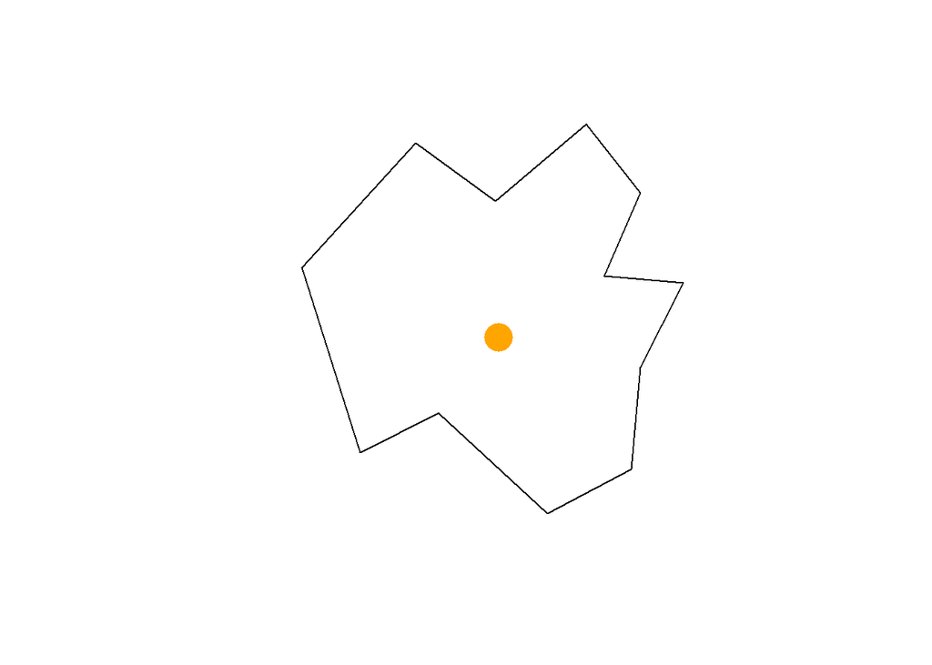

```r
  plot(Poly)
  plot(Pt,add=TRUE,pch=16,col='orange',cex=3)
```

- You have more control over the plot with the `ggplot2` package. But… it comes with a cost-very complicated.
- Here is the plot with ggplot2

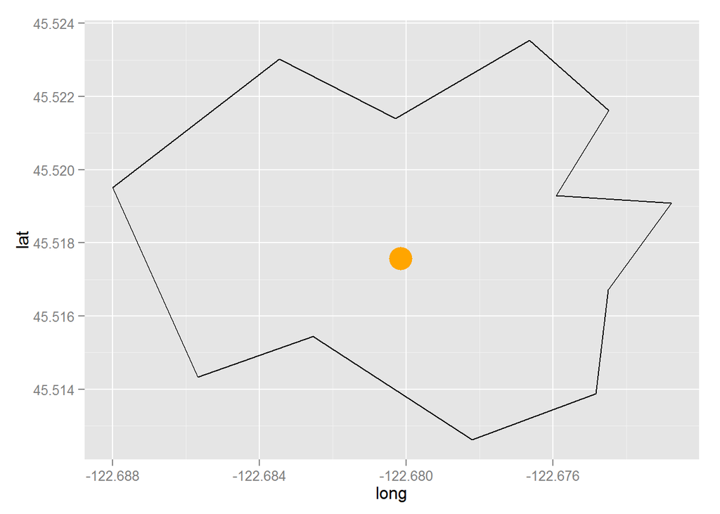

```r
  ggplot(Poly,aes(x=long, y=lat)) + geom_path() + geom_point(data=Pt@data, aes(x=lon, y=lat),shape=16,color='orange',size=8)
```

- With `ggplot2` and the `ggmap` package we can add a satelite (or other) image from googlemaps.

[figure not shown]

```r
    #get the image
      map<-ggmap(get_googlemap(center=c(lon=Pt@data$lon,lat=Pt@data$lat),
            zoom=15, #large numbers = larger scale (i.e zoomed in)
            maptype='satellite', #also hybrid/terrain/roadmap
            scale = 2), #resolution scaling, 1 (low) or 2 (high)
            size = c(600, 600), #size of the image to grab
            extent='device', #can also be "normal" etc
            darken = 0) #you can dim the map when plotting on top
    #plot location on the image
      map+geom_point(data=Pt@data, aes(x=lon, y=lat),shape=16,color='orange',size=8)+
        geom_path(data=Poly,aes(x=long, y=lat),size=2,colour='green')
```

- Nice image but not interactive
- For interactive maps there are some new packages such as `leafletR` available (see https://rstudio.github.io/leaflet/)
- A newer version of leaflet (leafletR) is now available on CRAN
- The first step is to setup the map and add a base map from “open street map”

```r
#build the map without "pipes"
  m<-leaflet() #setup map
  m<-addTiles(m) #add open street map data
  m
```

[interactive chart not shown]

- Now we can add a marker with our current location

```r
  m<-addMarkers(m,lng=Pt@data$lon, lat=Pt@data$lat, popup="We R Here")  #add point location
  m
```

[interactive chart not shown]

- and finally we add the polygon around our location

```r
  m<-addPolygons(m,data=Poly, weight=2) #add polygon
  m
```

[interactive chart not shown]

- leaflet maps can also be built with “pipes” (see code below)

```r
#or build the map with "pipes"
  leaflet() %>%   #setup map
  addTiles() %>%  #add open street map data
  addMarkers(lng=Pt@data$lon, lat=Pt@data$lat, popup="We R Here") %>%  #add point location
  addPolygons(data=Poly, weight=2) #add polygon
```

- Leaflet is great but does not currently work easily with projected data
- Jeff Hollister is developing an interactive map viewer that does work with projected data. His package is called quickmapper and Jeff demonstrate it later if there is time.
- We can also view the files in GoogleEarth (if loaded on your computer). But again this approach will not work with projected data.

```r
  shell.exec('LocPt.kml')  #Start GE and add Pt location
  shell.exec('LocPoly.kml') #Now add the Polygon
```

## Exercise 2

### Visualizing spatial data in R

1. Use the `plot` command to view “LocPt.shp” and “LocPoly.shp”
2. If you want more of a challenge try ‘ggplot2’ or ‘leafletR’
3. For windows users with the Google Earth you can also load the kml files (“LocPt.kml” and “LocPoly.kml”)

## Working with rasters

```r
#get the NLCD grid data-to repeat this is time cosuming; the final raster is available on github
  NLCD<-raster('C:/Bryan/EPA/Data/nlcd_2011_landcover_2011_edition_2014_10_10/nlcd_2011_landcover_2011_edition_2014_10_10.img')  #change location to match your directory structure

#NLCD includes all lower 48 states.  Reduce to bbox(Pt) + 10km
    #reproject Pt to match NLCD
      PtAlb<-spTransform(Pt,proj4string(NLCD))
      #define extent based on bbox(PtAlb)+100km
        B<-bbox(PtAlb)
        Add<-10000
        Extent<-c(B[1,1]-Add,B[1,2]+Add,B[2,1]-Add,B[2,2]+Add)
      #Crop NLCD
        NLCDpdx<-crop(NLCD,Extent)

#add colortable
  #get gex colors from Jeff's miscPackage
    ct <- system.file("extdata/nlcd_lookup.csv", package = "miscPackage")
    ct <- read.csv(ct, stringsAsFactors = FALSE)
  #add colors 1:256
    ctbl <- rep("#000000", 256)
  #update non-NULL colors
    ctbl[ct$code + 1] <- ct$hex
    NLCDpdx@legend@values <- ct$code
    NLCD@legend@colortable <- ctbl
    NLCD@legend@names <- ct$label

#export cropped NLCD as geotiff
  writeRaster(NLCDpdx, filename="NLCDpdx.tif", format="GTiff", overwrite=TRUE)
```

- Let’s get the raster data and look at it

```r
NLCD<-raster("../files/NLCDpdx.tif")  #simple read a raster image with the raster package.

slotNames(raster) #get a list of the "slot" names for the object
```

```
## [1] ".Data"      "generic"    "package"    "group"      "valueClass"
## [6] "signature"  "default"    "skeleton"
```

- We can use the `values` method to look at the raster data categories.

```r
table(values(NLCD))
```

```
##
##     11     21     22     23     24     31     41     42     43     52
##  20355  36829 131456 125320  62889    926   7345  26794  22077   1573
##     71     81     82     90     95
##   2156   2805    453   1507   1737
```

- Need to interpret the codes
- Fortunately we can translate the codes into the NLCD Land Use / Land Cover Categories
- Jeff has a lookup table we’ll use

```r
#Load the look up table
  ct <- system.file("extdata/nlcd_lookup.csv", package = "miscPackage")
  ct <- read.csv(ct, stringsAsFactors = FALSE)
  ct  #view the table
```

```
##    code     hex                        label
## 1    11 #5475A8                   Open Water
## 2    12 #FFFFFF           Perennial Ice/Snow
## 3    21 #E8D1D1        Developed, Open Space
## 4    22 #E29E8C     Developed, Low Intensity
## 5    23 #FF0000  Developed, Medium Intensity
## 6    24 #B50000    Developed, High Intensity
## 7    31 #D2CDC0 Barren Land (Rock/Sand/Clay)
## 8    41 #85C77E             Deciduous Forest
## 9    42 #38814E             Evergreen Forest
## 10   43 #38814E                 Mixed Forest
## 11   51 #AF963C                  Dwarf Scrub
## 12   52 #DCCA8F                  Scrub/Shrub
## 13   71 #FDE9AA         Grassland/Herbaceous
## 14   72 #D1D182            Sedge/Herbaceuous
## 15   73 #A3CC51                      Lichens
## 16   74 #82BA9E                         Moss
## 17   81 #FBF65D                  Pasture/Hay
## 18   82 #CA9146             Cultivated Crops
## 19   90 #C8E6F8               Woody Wetlands
## 20   95 #64B3D5 Emergent Herbaceous Wetlands
```

```r
#get the data from the raster
  codes<-data.frame(code=values(NLCD))
#merge with the lookup table
  Values<-merge(codes,ct,by='code',all.x=T)

#Now we can view the data
table(Values$label,useNA='ifany')
```

```
##
## Barren Land (Rock/Sand/Clay)             Cultivated Crops
##                          926                          453
##             Deciduous Forest    Developed, High Intensity
##                         7345                        62889
##     Developed, Low Intensity  Developed, Medium Intensity
##                       131456                       125320
##        Developed, Open Space Emergent Herbaceous Wetlands
##                        36829                         1737
##             Evergreen Forest         Grassland/Herbaceous
##                        26794                         2156
##                 Mixed Forest                   Open Water
##                        22077                        20355
##                  Pasture/Hay                  Scrub/Shrub
##                         2805                         1573
##               Woody Wetlands
##                         1507
```

- We’ll use base graphics to plot this raster image

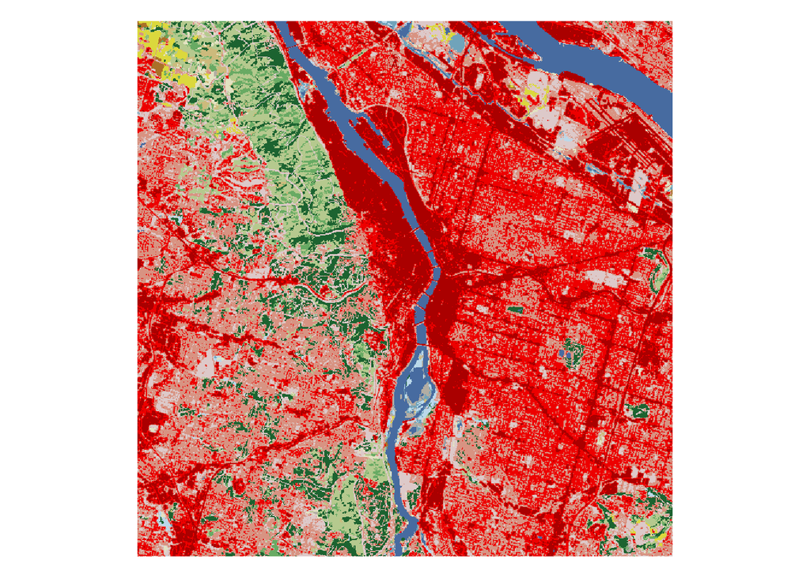

```r
plot(NLCD)
```

- add our location and surrounding polygon

```r
plot(NLCD)
```

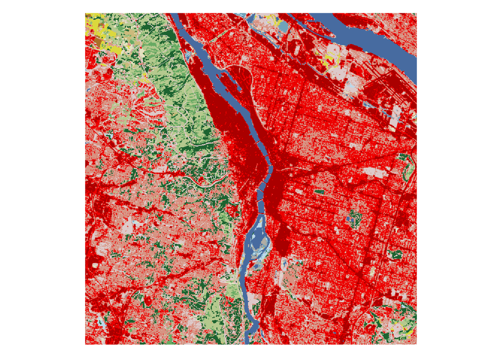

```r
plot(Pt,add=T,pch=4,col='white',cex=1.5,lwd=2)
plot(Poly,add=T,lwd=3,col=NA,border='black')
```

- nothing happens due to differences in projection
- view projection information

```r
  #Coordinate reference system for the raster
    proj4string(NLCD)
```

```
## [1] "+proj=aea +lat_1=29.5 +lat_2=45.5 +lat_0=23 +lon_0=-96 +x_0=0 +y_0=0 +ellps=GRS80 +towgs84=0,0,0,0,0,0,0 +units=m +no_defs"
```

```r
#Coordinate reference system for point location
    proj4string(Pt)
```

```
## [1] "+proj=longlat +datum=WGS84 +no_defs +ellps=WGS84 +towgs84=0,0,0"
```

```r
#Coordinate reference system for polygon location
    proj4string(Poly)
```

```
## [1] "+proj=longlat +datum=WGS84 +no_defs +ellps=WGS84 +towgs84=0,0,0"
```

- We could change to the raster to WGS84 or
- Change the locations to Albers
- Since we will want to keep albers for analysis convert the locations

```r
  #reproject Pt to match NLCD
      PtAlb<-spTransform(Pt,proj4string(NLCD))
  #reproject Polyg to match NLCD
      PolyAlb<-spTransform(Poly,proj4string(NLCD))
```

- now we can add PtAlb and PolyAlb to the NLCD plot

```r
plot(NLCD)
```

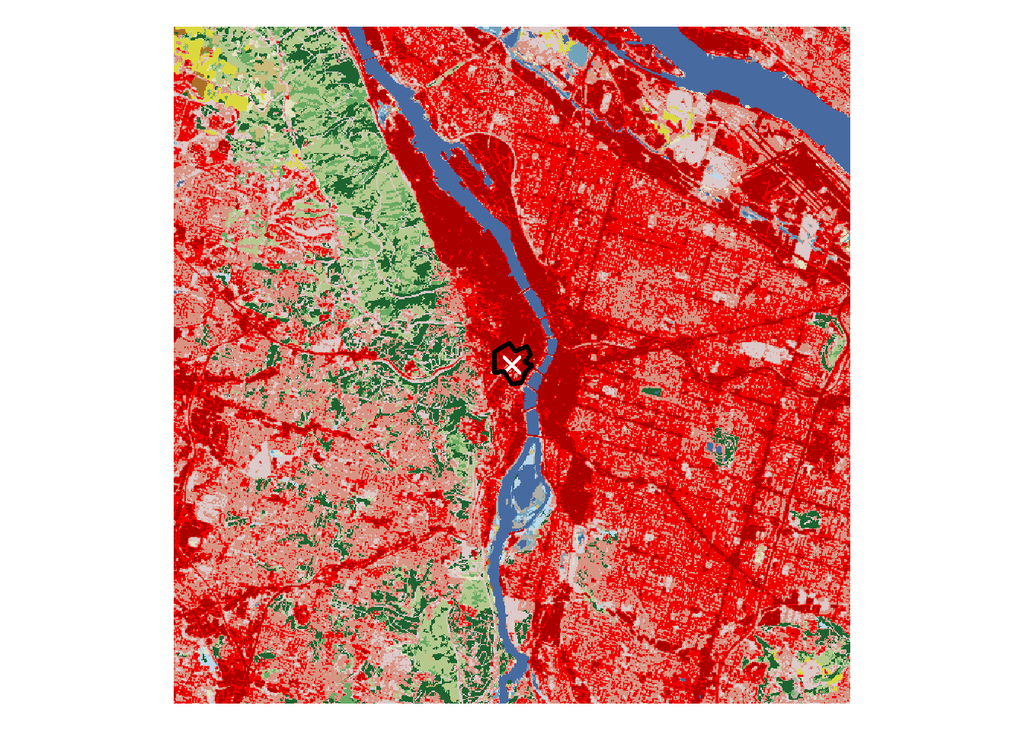

```r
plot(PtAlb,add=T,pch=4,col='white',cex=1.5,lwd=2)
plot(PolyAlb,add=T,lwd=3,col=NA,border='black')
```

- add a legend (we’ll use the same lookup table we used above)

```r
    plot(NLCD)
```

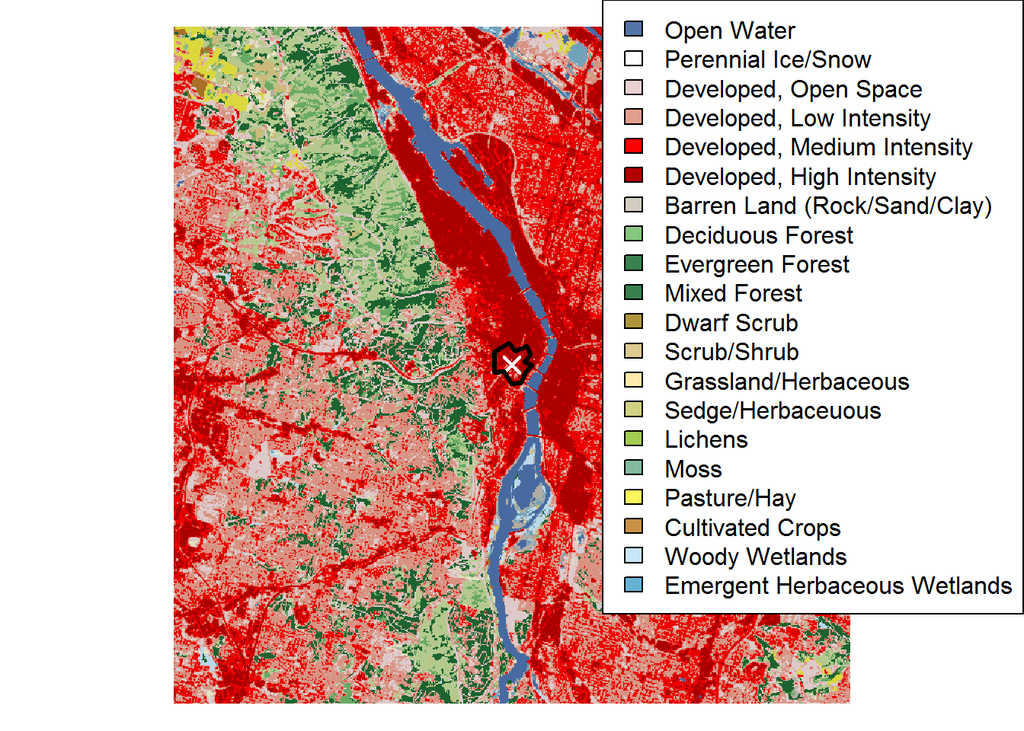

```r
    plot(PtAlb,add=T,pch=4,col='white',cex=1.5,lwd=2)
    plot(PolyAlb,add=T,lwd=3,col=NA,border='black')
  #add legend
    legend('topright',ct$label,fill=ct$hex)
```

```r
# Now some simple GISy stuff.  Select, buffer, clip and save

#add a buffer around our current location
  bufWidth<-1000 #in meters
  PtBuffer<-gBuffer(PtAlb,width=bufWidth,id=PtAlb[["ID"]])
    #this is a SpatialPolygons object
      class(PtBuffer)
```

```
## [1] "SpatialPolygons"
## attr(,"package")
## [1] "sp"
```

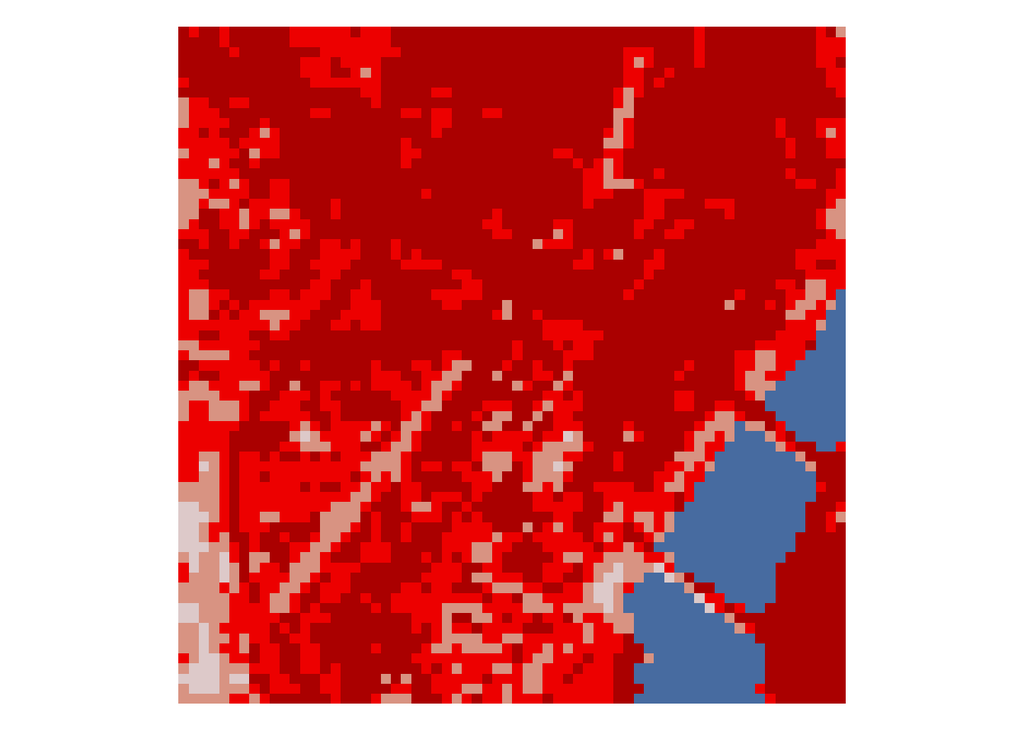

```r
#If we want to add attributes later we will need to convert it to a SpatialPolygonsDataFrame.  We'll add the attributes from PtAlb
  PtBuffer<-SpatialPolygonsDataFrame(PtBuffer,PtAlb@data)

#Now we can add data if we want just like any other data frame
  PtBuffer@data$BufferWidthM[1]<-bufWidth

# we can use the crop command to clip the NLCD data to the buffer
  bufNLCD<-crop(NLCD,PtBuffer)

# when we plot the data we notice that the resulting raster is square rather than round as we expected.
  plot(bufNLCD)
```

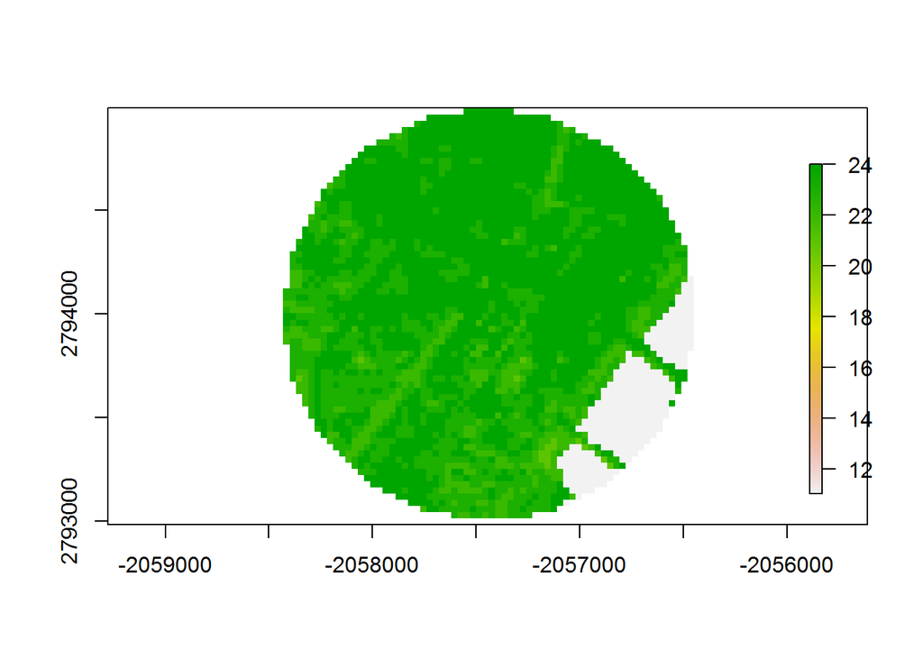

```r
# to limit the NLCD data to the circular buffer we change use a mask to assign the values outside the buffer to NA (missing)
  bufNLCD<-mask(crop(NLCD,PtBuffer),PtBuffer)

# now the shape is correct but we lost the color table
  plot(bufNLCD)
```

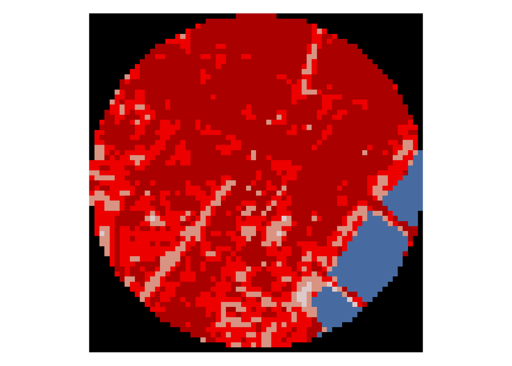

```r
# this will not affect the analysis but it doesn't look right so we can fix it
  bufNLCD@legend@colortable<-NLCD@legend@colortable

# success
  plot(bufNLCD)
```

```r
#Now calcualte total proportion of each LULC and save to a data.frame
  lulc<-freq(bufNLCD)

#clean it up by removing the NA values
  lulc<-as.data.frame(lulc[!is.na(lulc[,1]),])

#calculate the proportions in each class
  lulc$proportion<-round(lulc$count/sum(lulc$count),3)

# calculate the total area of each class based on 30m x 30m grid cell size
  lulc$areaM2<-lulc$count*30*30

# finally, add the labels
    lulc<-merge(ct,lulc,by.x='code',by.y='value',all.y=TRUE)

# what a surprise, it is mostly developed land around the hotel
    lulc
```

```
##   code     hex                       label count proportion  areaM2
## 1   11 #5475A8                  Open Water   279      0.081  251100
## 2   21 #E8D1D1       Developed, Open Space    16      0.005   14400
## 3   22 #E29E8C    Developed, Low Intensity   316      0.092  284400
## 4   23 #FF0000 Developed, Medium Intensity   903      0.263  812700
## 5   24 #B50000   Developed, High Intensity  1917      0.559 1725300
```

## Exercise 3

### Working with rasters

1. Use the command `raster` to load the NLCD data (“NLCDpdx.tif”)
2. Plot the data
3. Add LocPt and LocPoly (you will need to reproject)
4. Use `values` and `freq` to the analyze the raster.
5. We are done.